# Assignment : activity monitoring

Raphael Villedieu

September 18, 2017

## Loading and preprocessing the data

```r
if(!file.exists('activity.csv')){
    unzip('activity.zip')
}
df<-read.csv("activity.csv")
```

## What is the mean total number of steps taken per day?

```r
library(ggplot2)
```

```r
totalnofsteps <- tapply(df$steps, df$date, FUN = sum, na.rm = TRUE)
```

2. Histogram of the total number of steps taken each day:

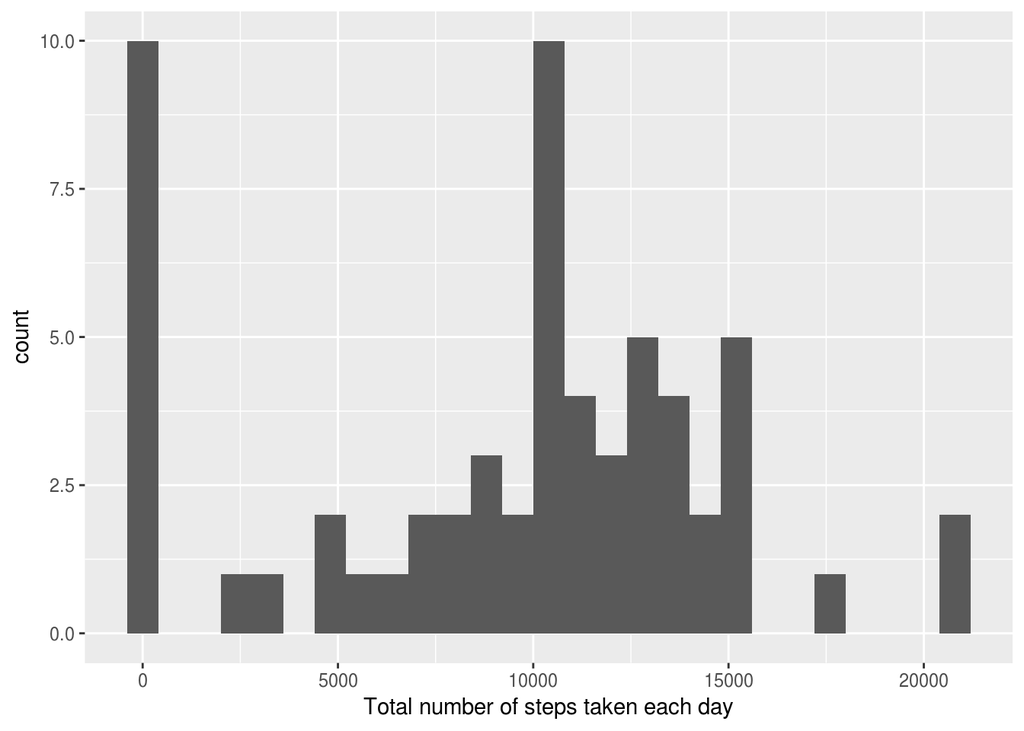

```r
qplot(totalnofsteps, xlab = "Total number of steps taken each day", binwidth=800)
```

3. The mean and median number of steps per day are:

```r
mean(totalnofsteps, na.rm=TRUE)
```

```
## [1] 9354.23
```

```r
median(totalnofsteps, na.rm=TRUE)
```

```
## [1] 10395
```

## What is the average daily activity pattern?

1. Times series plot of the 5-minute interval (x-axis) and the average number of steps taken, averaged across all days (y-axis)

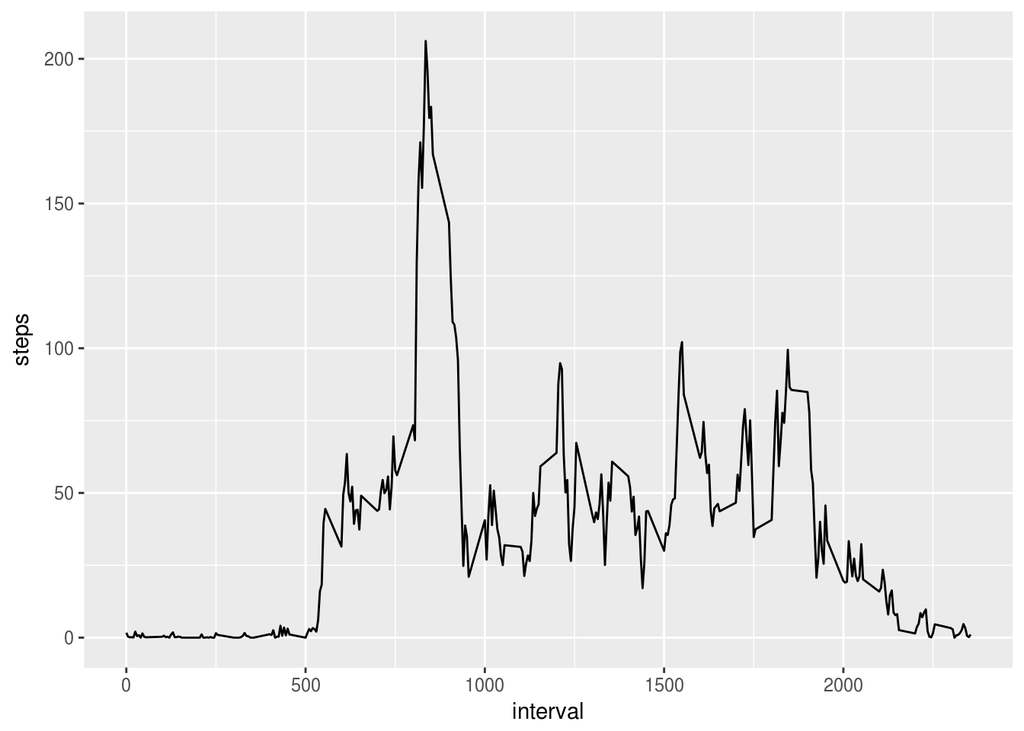

```r
ag<-aggregate(x=list(steps=df$steps),by=list(interval=df$interval),FUN=mean,na.rm=TRUE)
ggplot(data=ag, aes(x = interval, y = steps))+geom_line()
```

2. The 5-minute interval which contains the maximum number of steps is

```r
ag[which.max( ag$steps),1]
```

```
## [1] 835
```

## Inputing missing values

1. The total number of rows with NAs is:

```r
sum(is.na(df$steps))
```

```
## [1] 2304
```

2. Fill in the NAs with the mean for the corresponding 5-minute interval

We can iterate over the rows and if a step is NA, replace it with the mean correponding to the interval. We already computed the means (ag)

3. Let’s do it!

```r
# make a copy of data
dfnoNA <- df
for (r in 1:nrow(df)){ # iterate over all rows of data
  if ( is.na(df$steps[r])) { # if step is NA
    interval <- df$interval[r] # get the corresponding interval
    # retrieve mean for the interval
    meanForInterval <- ag$steps[ag$interval == interval]
    # fill in value
    dfnoNA$steps[r] <- meanForInterval
    }
  }
```

4. Plot a histogram

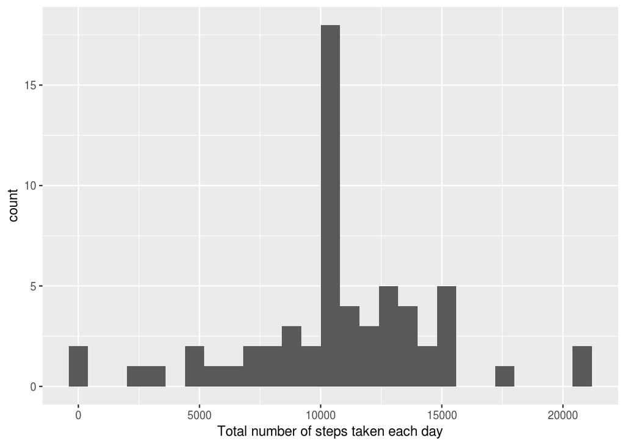

```r
totalnofsteps <- tapply(dfnoNA$steps, dfnoNA$date, FUN = sum, na.rm = TRUE)
qplot(totalnofsteps, xlab = "Total number of steps taken each day", binwidth=800)
```

The mean and median number of steps per day are now:

```r
mean(totalnofsteps, na.rm=TRUE)
```

```
## [1] 10766.19
```

```r
median(totalnofsteps, na.rm=TRUE)
```

```
## [1] 10766.19
```

## weekdays and weekends

1. Create a new factor variable in the dataset with two levels : weekday and weekend

```r
# Set language to english
Sys.setlocale("LC_TIME", "C")
```

```
## [1] "C"
```

```r
# add the new column
dfnoNA$daytype <- "weekday"
dfnoNA$daytype[weekdays(as.Date(dfnoNA$date)) %in% c("Saturday","Sunday")] <- "weekend"
# convert it to a factor
dfnoNA$daytype <- as.factor(dfnoNA$daytype)
```

2. Panel plot

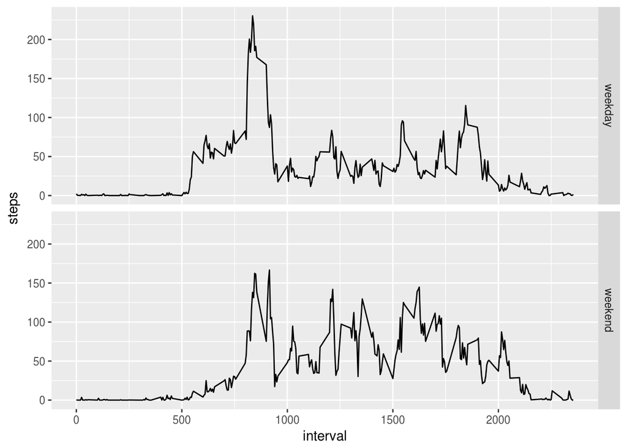

```r
# recompute the means for both day type
agnoNA<-aggregate(x=list(steps=dfnoNA$steps),by=list(interval=dfnoNA$interval, daytype=dfnoNA$daytype),FUN=mean)
# plot as panel plot (with ggplot2)
ggplot(data=agnoNA, aes(x = interval, y = steps))+geom_line()+facet_grid(daytype ~ .)
```